# TRATAMIENTO DE DATOS CON R

Joaquín Planelles Romero e Isabel Padilla Sánchez

octubre de 2021

# **Manipulación de filas**

Como vimos en la primera parte de esta unidad, dplyr trabaja de forma vectorial, es decir, sus comandos operan con los datos tanto por filas como por columnas. Las principales funciones de esta librería son 8. Ya conocéis tres de ellas que se utilizan para el tratamiento de las columnas (`rename()`, `select()` y `mutate()`). En este apartado nos centramos en funciones específicas para operar con filas. La principal es `filter()` aunque veremos otras que también nos serán de utilidad. Por último, en la siguiente sección trataremos funciones de sumarización que ya explicaremos lo que son pero para que os vayan sonando, son `summarise()` y `group_by()`. A modo de resumen:

| Comando | Tratamiento |
| --- | --- |
| `mutate()` `select()` `rename()` | columnas |
| `filter()` `arrange()` `distinct()` | filas |
| `summarise()` `group_by()` | sumarización |

Recordad que cada comando resuelve un problema simple pero si los concatenamos mediante %>% (tuberías), permiten resolver cuestiones complejas.

# Manipulación de filas. 1 - filter

El comando de dplyr fundamental para operar por filas es `filter()` y nos permite obtener un subconjunto de observaciones que cumplen una determinada condición.

Comando

Utilidad

Descripción

`tabla <- datos %>% filter(condición)`

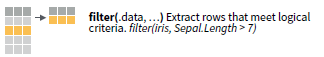

Se obtiene un subconjunto de observaciones que cumplen una determinada condición

En la chuleta podemos encontrar los distintos operadores lógicos y booleanos que nos permiten delimitar los datos según la condición impuesta. A continuación tenéis un cuadro resumen con las posibles condiciones y cómo sería su formulación en lenguaje dplyr:

| sentencia con filter | filtramos las filas que… |
| --- | --- |
| filter(variable **==** valor) | son **iguales** a un valor |
| filter(variable **!=** valor) | sons **distintas** a un valor |
| filter(variable **>** valor) | son **mayores** a un valor |
| filter(variable **<** valor) | son **menores** a un valor |
| filter(variable **%in%** c(‘valor1’,‘valor2’,…) | son **iguales** a un conjunto de valores |
| filter( **is.na** (variable)) | son na (las celdas están **vacías**) |
| filter( **!is.na** (variable)) | no son na (las celdas están **no vacías****) |
| filter(condición 1 **&** condición 2) | cumplen las dos condiciones |
| filter(condición 1 **\|** condición 2) | o cumplen una condición o la otra |

*!!!!IMPORTANTE¡¡¡¡* Hay que tener en cuenta el tipo de dato que tenemos, es decir, si por ejemplo es de tipo carácter tendremos que meter la característica que queremos filtrar entre comillas simples o dobles (**’ ’** ó **” “** )

Para aprender a utilizar filter vamos a coger el fichero con información de los contenidos de la plataforma **Netflix** de tidytuesday que recoge las siguientes variables:

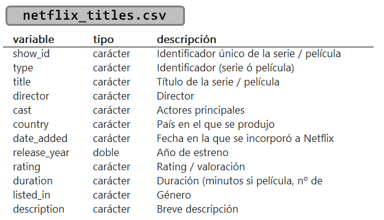

Podéis cargar el fichero mediante la siguiente línea de código y explorar después su contenido mediante los comandos que ya se han visto anteriormente: `glimpse()`, `head()` o `view()`.

```r
library(tidyverse)
netflix_titles <- readr::read_csv('https://raw.githubusercontent.com/rfordatascience/tidytuesday/master/data/2021/2021-04-20/netflix_titles.csv')
```

Empezamos con un ejemplo sencillo, supongamos que queremos saber qué títulos de la plataforma se estrenaron en 2020 (el último año para el que se tiene información completa).

```r
Ejemplo <- netflix_titles %>% filter(release_year==2020)
Ejemplo
```

```
## # A tibble: 868 x 12
##    show_id type   title  director cast    country date_added release_year rating
##    <chr>   <chr>  <chr>  <chr>    <chr>   <chr>   <chr>             <dbl> <chr>
##  1 s1      TV Sh~ 3%     <NA>     João M~ Brazil  August 14~         2020 TV-MA
##  2 s25     TV Sh~ SAINT~ <NA>     Bryson~ Japan   January 2~         2020 TV-14
##  3 s27     TV Sh~ (Un)W~ <NA>     <NA>    United~ August 12~         2020 TV-MA
##  4 s28     Movie  #Alive Cho Il   Yoo Ah~ South ~ September~         2020 TV-MA
##  5 s30     TV Sh~ #blac~ <NA>     Kenya ~ United~ April 17,~         2020 TV-MA
##  6 s31     Movie  #cats~ Michael~ <NA>    Canada  February ~         2020 TV-14
##  7 s33     Movie  #Frie~ Rako Pr~ Adipat~ Indone~ June 28, ~         2020 TV-G
##  8 s44     Movie  Òlòtu~ Kenneth~ Beverl~ Nigeria October 2~         2020 TV-MA
##  9 s54     TV Sh~ 100 H~ <NA>     Zainab~ United~ March 13,~         2020 TV-14
## 10 s58     Movie  100% ~ Jastis ~ Anisa ~ Indone~ January 7~         2020 TV-14
## # ... with 858 more rows, and 3 more variables: duration <chr>,
## #   listed_in <chr>, description <chr>
```

Como vemos son un total de 868 títulos. Si además queremos saber cuántos de ellos son películas tendríamos que añadir al filtro una condición más.

```r
Ejemplo <- netflix_titles %>% filter(release_year==2020 & type=='Movie')
Ejemplo
```

```
## # A tibble: 411 x 12
##    show_id type  title  director  cast    country date_added release_year rating
##    <chr>   <chr> <chr>  <chr>     <chr>   <chr>   <chr>             <dbl> <chr>
##  1 s28     Movie #Alive Cho Il    Yoo Ah~ South ~ September~         2020 TV-MA
##  2 s31     Movie #cats~ Michael ~ <NA>    Canada  February ~         2020 TV-14
##  3 s33     Movie #Frie~ Rako Pri~ Adipat~ Indone~ June 28, ~         2020 TV-G
##  4 s44     Movie Òlòtu~ Kenneth ~ Beverl~ Nigeria October 2~         2020 TV-MA
##  5 s58     Movie 100% ~ Jastis A~ Anisa ~ Indone~ January 7~         2020 TV-14
##  6 s74     Movie 18 Pr~ Francesc~ Vittor~ Italy   May 8, 20~         2020 TV-MA
##  7 s107    Movie 365 D~ Barbara ~ Anna-M~ Poland  June 7, 2~         2020 TV-MA
##  8 s108    Movie 37 Se~ Hikari    Mei Ka~ Japan   January 3~         2020 TV-MA
##  9 s148    Movie A Bab~ Rachel T~ Tamara~ United~ October 1~         2020 TV-PG
## 10 s155    Movie A Cal~ Shaun Pa~ Lauren~ United~ December ~         2020 PG-13
## # ... with 401 more rows, and 3 more variables: duration <chr>,
## #   listed_in <chr>, description <chr>
```

En este caso, el número de títulos estrenados en 2020 y que eran películas, son 411. Fijaos que en el filtro una de las variables, el año de lanzamiento (*release_year*), es de tipo numérico mientras que el tipo de título (*type*) es carácter. En este último caso, la categoría de la variable *type* vendrá escrito de forma literal a como se encuentra en la tabla y entre comillas (simples o dobles, las dos opciones funcionan).

# Manipulación de filas. 2 - arrange

En muchas ocasiones nos puede interesar encontrar las filas del tibble ordenadas según alguna o algunas columnas (que pueden ser numéricas o carácter). Pues para esta acción también tenemos un comando, `arrange()`. Por defecto las ordena de forma ascendente y si las queremos de forma descendente se lo tendremos que indicar en los argumentos.

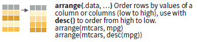

El conjunto de datos históricos sobre los **Juegos Olímpicos** modernos incluye información de todos los Juegos desde Atenas 1896 hasta Río 2016. Supongamos que queremos saber quiénes son los deportistas más jóvenes que han participado a lo largo de todos los juegos olímpicos celebrados en el periodo.

```r
library(tidyverse)
olympics <- readr::read_csv('https://raw.githubusercontent.com/rfordatascience/tidytuesday/master/data/2021/2021-07-27/olympics.csv')
Ejemplo <- olympics %>% arrange(age)
head(Ejemplo)
```

```
## # A tibble: 6 x 15
##      id name     sex     age height weight team   noc   games  year season city
##   <dbl> <chr>    <chr> <dbl>  <dbl>  <dbl> <chr>  <chr> <chr> <dbl> <chr>  <chr>
## 1 71691 Dimitri~ M        10     NA     NA Ethni~ GRE   1896~  1896 Summer Athi~
## 2 22411 Magdale~ F        11    152     NA Great~ GBR   1932~  1932 Winter Lake~
## 3 37333 Carlos ~ M        11     NA     NA Spain  ESP   1992~  1992 Summer Barc~
## 4 40129 Luigina~ F        11     NA     NA Italy  ITA   1928~  1928 Summer Amst~
## 5 47618 Sonja H~ F        11    155     45 Norway NOR   1924~  1924 Winter Cham~
## 6 51268 Beatric~ F        11    151     38 Roman~ ROU   1968~  1968 Winter Gren~
## # ... with 3 more variables: sport <chr>, event <chr>, medal <chr>
```

Como veis en 1896 hubo un participante con 10 años. Del mismo modo podríamos ver cuál ha sido el deportista más longevo. Ejecutando las siguientes líneas que ordenan de forma descendente el tibble según la variable edad, descubrimos que en 1928 participó una persona en los juegos olímpicos con 97 años.

```r
Ejemplo <- olympics %>% arrange(desc(age))
head(Ejemplo)
```

```
## # A tibble: 6 x 15
##       id name    sex     age height weight team   noc   games  year season city
##    <dbl> <chr>   <chr> <dbl>  <dbl>  <dbl> <chr>  <chr> <chr> <dbl> <chr>  <chr>
## 1 128719 John Q~ M        97     NA     NA Unite~ USA   1928~  1928 Summer Amst~
## 2  49663 Winslo~ M        96     NA     NA Unite~ USA   1932~  1932 Summer Los ~
## 3  31173 Thomas~ M        88     NA     NA Unite~ USA   1932~  1932 Summer Los ~
## 4  31173 Thomas~ M        88     NA     NA Unite~ USA   1932~  1932 Summer Los ~
## 5  31173 Thomas~ M        88     NA     NA Unite~ USA   1932~  1932 Summer Los ~
## 6   5146 George~ M        84     NA     NA Great~ GBR   1948~  1948 Summer Lond~
## # ... with 3 more variables: sport <chr>, event <chr>, medal <chr>
```

# Manipulación de filas. 3 - otros comandos

Para el tratamiento de filas existen otros comandos también muy útiles. Algunos de ellos son los siguientes:

Comando

Utilidad

Descripción

`distinct()`

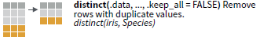

Elimina las filas duplicadas

`sample_n()` y`sample_frac()`

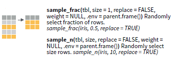

Extraen muestras de los datos

`slice()` y `top_n()`

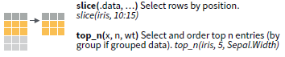

Permite seleccionar filas por posiciones

Para entender mejor cómo se utilizan estas funciones y su utilidad dentro del tratamiento de datos con dplyr, veamos algunos ejemplos:

### 1. Función `distinct`

Volvemos a utilizar el tibble que contiene información sobre la plataforma **Netflix**. Supongamos que queremos saber las distintas tipos en los que clasifica los títulos. Simplemente tendríamos que seleccionar la columna que nos interesa (type) y utilizar `distict()`, con ello eliminamos todos los duplicados.

```r
Ejemplo  <- netflix_titles %>% select(type)%>% #Seleccionamos la columna type que contiene el tipo de lanzamiento
                               distinct()      #Eliminamos filas duplicadas
Ejemplo
```

```
## # A tibble: 2 x 1
##   type
##   <chr>
## 1 TV Show
## 2 Movie
```

### 2. Función `sample_n`

Supongamos ahora que del fichero del **Censo 2011** queremos extraer una muestra aleatoria con reemplazamiento de 200 personas. Para comprobar que efectivamente hemos extraído 200 filas, usamos el comando de dplyr `count()` que nos muestra el número de registros del tibble.

```r
Ejemplo <- DATOS_HP %>% sample_n(200,replace = TRUE)
count(Ejemplo)
```

```
##     n
## 1 200
```

### 3. Función `slice`

Como veis la mayoría de los nombres de los comandos (en inglés) hacen refereccia a la acción que llevan a cabo. Slice significa ‘rebanada’, pues bien, este comando selecciona filas por posiciones, por ejemplo, del fichero de **ikea** podemos coger solo las filas de la 3 a la 6 de la siguiente forma:

```r
ikea <- readr::read_csv('https://raw.githubusercontent.com/rfordatascience/tidytuesday/master/data/2020/2020-11-03/ikea.csv')
Ejemplo  <- ikea %>% slice(3:6)
Ejemplo
```

```
## # A tibble: 4 x 14
##      X1  item_id name    category  price old_price sellable_online link
##   <dbl>    <dbl> <chr>   <chr>     <dbl> <chr>     <lgl>           <chr>
## 1     2  9333523 NORDVI~ Bar furn~  2095 No old p~ FALSE           https://www.~
## 2     3 80155205 STIG    Bar furn~    69 No old p~ TRUE            https://www.~
## 3     4 30180504 NORBERG Bar furn~   225 No old p~ TRUE            https://www.~
## 4     5 10122647 INGOLF  Bar furn~   345 No old p~ TRUE            https://www.~
## # ... with 6 more variables: other_colors <chr>, short_description <chr>,
## #   designer <chr>, depth <dbl>, height <dbl>, width <dbl>
```

# Preguntas de auto-evaluación

El objetivo de las siguientes preguntas es que podáis auto-evaluar si habéis adquirido los conocimientos. Encontraréis las respuestas en la pestaña de soluciones.

Para la resolución de algunos de estos ejercicios es necesario utilizar los ficheros planos del censo de 2011 que os hemos facilitado.

- **Pregunta 1**. ¿Cuáles de los siguientes comandos se utiliza para el tratamiento de filas?
  1. select()
  2. mutate()
  3. distinct()
  4. transmutate()
- **Pregunta 2**. Del fichero nombres de la librería datos que hace referencia los nombres de recién nacidos. Averigua a cuántas filas tiene el tibble en las que aparece el nombre de Shakira.
  1. 10
  2. 5
  3. 48
  4. 101
- **Pregunta 3**. ¿En cuántas series producidas en España del fichero de la plataforma Netflix, el nombre del director no está vacío?
  1. 2
  2. 30
  3. 0
  4. 10
- **Pregunta 4**. ¿Cuál es el precio del artículo más caro del fichero de **ikea**?
  1. 9.585 riales saudíes
  2. 7.787 riales saudíes
  3. 8.585 riales saudíes
  4. 9.753 riales saudíes
- **Pregunta 5**. En el fichero de viviendas del censo (DATOS_VE) ¿Dónde habría más viviendas en propiedad según los datos muestrales, en Huelva, en Jaén o Almería?
  1. Huelva
  2. Jaén
  3. Almería
  4. Huelva y Jaén

# Soluciones

A continuación se muestran, marcadas y en rojo, las soluciones a las preguntas de auto-evaluación

- **Pregunta 1**. ¿Cuáles de los siguientes comandos se utiliza para el tratamiento de filas?
  1. select()
  2. mutate()
  3. **distinct()**
  4. transmutate()
- **Pregunta 2**. Del fichero nombres de la librería datos que hace referencia los nombres de recién nacidos. Averigua a cuántas filas tiene el tibble en las que aparece el nombre de Shakira.
  1. **48**
  2. 5
  3. 10
  4. 101

  **En concreto, hemos utilizado el siguiente código para obtener el resultado:**

  ```r
  library(datos)
  P2 <- nombres %>% filter(nombre=='Shakira')
  count(P2)
  ```

  ```
  ## # A tibble: 1 x 1
  ##       n
  ##   <int>
  ## 1    48
  ```

- **Pregunta 3**. ¿En cuántas series producidas en España del fichero de la plataforma Netflix, el nombre del director no está vacío?
  1. 2
  2. 30
  3. 0
  4. **10**

  **En concreto, hemos utilizado el siguiente código para obtener el resultado:**

  ```r
  P3 <- netflix_titles %>% filter(type=='TV Show' & !is.na(director) & country=='Spain')
  count(P3)
  ```

  ```
  ## # A tibble: 1 x 1
  ##       n
  ##   <int>
  ## 1    10
  ```

- **Pregunta 4**. ¿Cuál es el precio del artículo más caro del fichero de **ikea**?
  1. **9.585 riales saudíes**
  2. 7.787 riales saudíes
  3. 8.585 riales saudíes
  4. 9.753 riales saudíes

  **En concreto, hemos utilizado el siguiente código para obtener el resultado:**

  ```r
  P4   <- ikea %>% arrange(desc(price)) %>% slice(1:1)
  ```

- **Pregunta 5**. En el fichero de viviendas del censo (DATOS_VE) ¿Dónde habría más viviendas en propiedad según los datos muestrales, en Huelva, en Jaén o Almería?
  1. Huelva
  2. **Jaén**
  3. Almería
  4. Huelva y Jaén

  **En concreto, hemos utilizado el siguiente código para obtener el resultado:**

  ```r
  P5_Huelva  <- DATOS_VE %>% filter(TENEN %in% c('1','2','3') & CPRO=='21')
  P5_Jaen    <- DATOS_VE %>% filter(TENEN %in% c('1','2','3') & CPRO=='23')
  P5_Almeria <- DATOS_VE %>% filter(TENEN %in% c('1','2','3') & CPRO=='04')
  ```